# Matplotlib高级图表：热力图与箱线图

## 教学目标

面向大一文科生讲解Matplotlib中的高级图表绘制方法，重点介绍热力图和箱线图的概念、应用场景及实现方法，结合人文社科领域的实际案例。

## 1. 热力图 (Heatmap)

### 1.1 定义与适用场景

**定义**：热力图是通过颜色变化来显示矩阵数据的二维图表，用颜色深浅表示数值大小。

**应用场景**：

- 社会科学：不同地区多项指标对比
- 经济学：相关系数矩阵可视化
- 心理学：问卷量表各维度相关性
- 教育学：学生各科成绩关联分析

### 1.2 基础热力图绘制

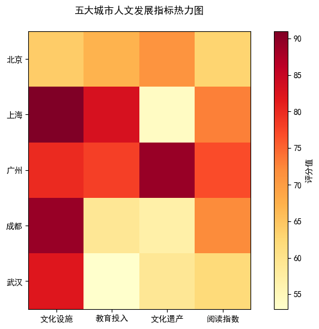

```python
import numpy as np
import matplotlib.pyplot as plt
# 设置中文显示
plt.rcParams['font.sans-serif'] = ['SimHei']
plt.rcParams['axes.unicode_minus'] = False
# 创建模拟数据：5个城市4项人文指标评分
cities = ['北京', '上海', '广州', '成都', '武汉']
indicators = ['文化设施', '教育投入', '文化遗产', '阅读指数']
data = np.random.randint(50, 95, size=(5, 4))  # 5城市×4指标
# 绘制基础热力图
plt.figure(figsize=(10, 6))
heatmap = plt.imshow(data, cmap='YlOrRd')  # 使用黄-橙-红色系
# 添加坐标轴标签
plt.xticks(np.arange(len(indicators)), indicators)
plt.yticks(np.arange(len(cities)), cities)
# 添加颜色条
plt.colorbar(heatmap, label='评分值')
# 添加标题
plt.title('五大城市人文发展指标热力图', pad=20)

# 显示图表
plt.show()
```

### 1.3 进阶热力图（带数值标注）

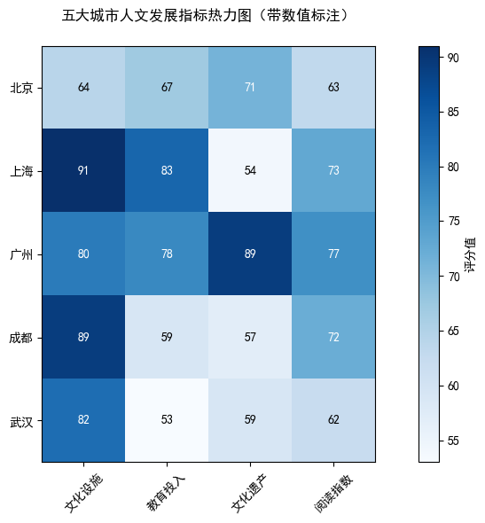

```python
plt.figure(figsize=(10, 6))
heatmap = plt.imshow(data, cmap='Blues')  # 更换为蓝色系

# 添加数值标注
for i in range(len(cities)):
    for j in range(len(indicators)):
        plt.text(j, i, f'{data[i,j]}',
                 ha='center', va='center',
                 color='w' if data[i,j] > 70 else 'k')  # 根据背景色调整文字颜色

#当数据值 data[i,j] > 70 时，文字颜色设为白色（w），否则设为黑色（k）。
#目的：通过黑白对比度适应不同背景色。例如，深色背景（如热力图中高值区域）适合白色文字，浅色背景（低值区域）适合黑色文字。

# 美化设置
plt.xticks(np.arange(len(indicators)), indicators, rotation=45)
plt.yticks(np.arange(len(cities)), cities)
plt.colorbar(heatmap, label='评分值')
plt.title('五大城市人文发展指标热力图（带数值标注）', pad=20)
plt.tight_layout()
plt.show()
```

### 1.4 人文社科案例练习

**任务**：分析不同省份文化产业各维度发展水平

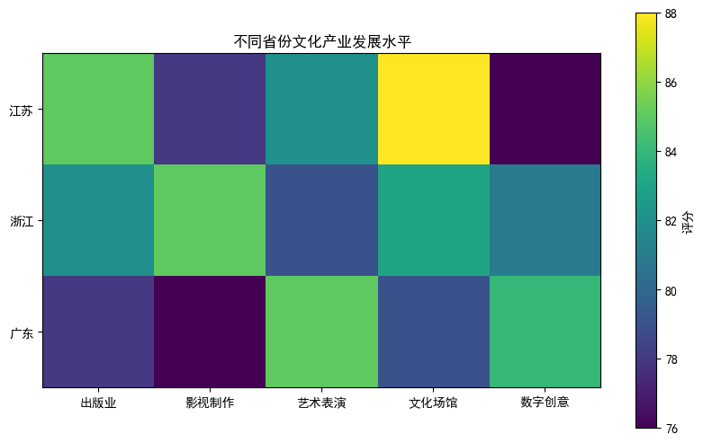

```python
provinces = ['江苏', '浙江', '广东']
dimensions = ['出版业', '影视制作', '艺术表演', '文化场馆', '数字创意']
culture_data = np.array([
    [85, 78, 82, 88, 76],
    [82, 85, 79, 83, 81],
    [78, 76, 85, 79, 84]
])

plt.figure(figsize=(10, 6))
plt.imshow(culture_data, cmap='viridis')
plt.xticks(np.arange(len(dimensions)), dimensions)
plt.yticks(np.arange(len(provinces)), provinces)
plt.colorbar(label='评分')
plt.title('不同省份文化产业发展水平')
plt.grid(False)
plt.show()
```

## 2. 箱线图 (Boxplot)

### 2.1 定义与适用场景

**定义**：箱线图又称盒须图，能够显示一组数据的分布情况，包括中位数、四分位数和异常值。

应用场景：

- 社会学：不同收入群体的消费水平比较
- 教育学：不同班级成绩分布对比
- 心理学：实验组与控制组的反应时分析
- 经济学：各地区房价分布研究

### 2.2 基础箱线图绘制

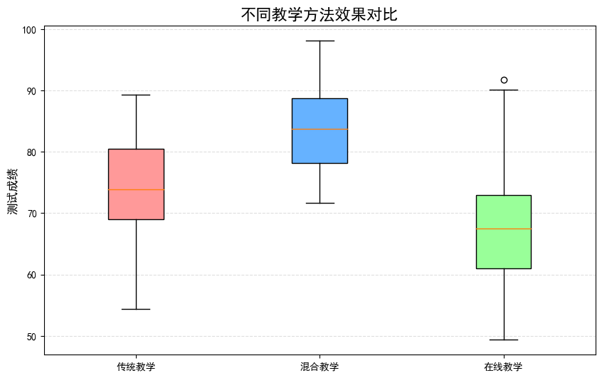

```python
import numpy as np
import matplotlib.pyplot as plt
# 设置中文显示
plt.rcParams['font.sans-serif'] = ['SimHei']
plt.rcParams['axes.unicode_minus'] = False

method1 = np.random.normal(75, 8, 50)
method2 = np.random.normal(85, 6, 50)
method3 = np.random.normal(70, 10, 50)
data = [method1, method2, method3]
labels = ['传统教学', '混合教学', '在线教学']

plt.figure(figsize=(10, 6))
box = plt.boxplot(data, labels=labels, patch_artist=True)

colors = ['#FF9999', '#66B2FF', '#99FF99']
for patch, color in zip(box['boxes'], colors):
    patch.set_facecolor(color)

plt.title('不同教学方法效果对比', fontsize=16)
plt.ylabel('测试成绩', fontsize=12)
plt.grid(axis='y', linestyle='--', alpha=0.4)

plt.show()
```

### 2.3 箱线图元素解析

[figure not shown]

- 中位数：箱体中间的线
- 四分位距(IQR)：箱体范围(Q1到Q3)
- 须线：通常为1.5倍IQR范围
- 异常值：超出须线的数据点

### 2.4 人文社科案例练习

**任务**：比较不同年龄段社交媒体使用时长

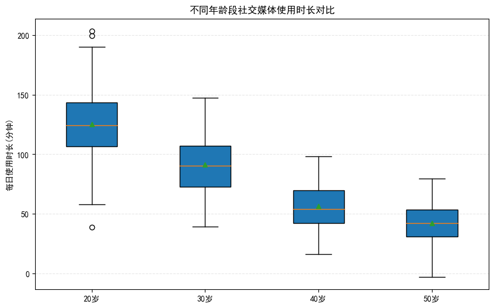

```python
age_20s = np.random.normal(120, 30, 100)
age_30s = np.random.normal(90, 25, 100)
age_40s = np.random.normal(60, 20, 100)
age_50s = np.random.normal(40, 15, 100)

data = [age_20s, age_30s, age_40s, age_50s]
labels = ['20岁', '30岁', '40岁', '50岁']

plt.figure(figsize=(10, 6))
plt.boxplot(data, labels=labels, patch_artist=True, showmeans=True)
plt.title('不同年龄段社交媒体使用时长对比')
plt.ylabel('每日使用时长(分钟)')
plt.grid(axis='y', linestyle='--', alpha=0.3)

plt.show()
```

## 3. 综合练习与作业

请根据上述示例自行完成热力图和箱线图综合练习。

```python
### 3.1 热力图实践
任务要求：

- 分析各省文化产业指标相关性

- 使用coolwarm色系

- 标注显著性标记（p<0.05）

实现步骤：

- 计算相关系数矩阵

- 设置vmin=-1, vmax=1

- 添加星号标注
```

### 3.2 箱线图实践

分组比较案例：

- 不同学历人群阅读量分布
- 城乡消费水平对比

## 附录：常用参数参考

### 热力图关键参数

| 参数 | 说明 | 示例值 |
| --- | --- | --- |
| `cmap` | 颜色映射 | `'viridis'`, `'plasma'`, `'YlOrRd'` |
| `vmin/vmax` | 值范围 | `vmin=0`, `vmax=100` |
| `annot` | 显示数值 | `annot=True` |
| `fmt` | 数值格式 | `fmt='.1f'` |
| `linewidths` | 单元格边线 | `linewidths=0.5` |

### 箱线图关键参数

| 参数 | 说明 | 示例值 |
| --- | --- | --- |
| `positions` | 箱体位置 | `[1,2,4,5]` |
| `widths` | 箱体宽度 | `widths=0.6` |
| `showmeans` | 显示均值 | `showmeans=True` |
| `meanline` | 均值线样式 | `meanline=True` |
| `notch` | 显示置信区间 | `notch=True` |

通过本课程的学习，希望同学们能够掌握这两种高级图表的绘制方法，在人文社科研究中更全面地展示和分析数据特征。